# Round_High_vs_Low

## 축구 데이터 - 2. 순위에 따른 라운드별 승 무 패 비교

```python
#라운드별 순위 승무패 비교
import pandas as pd

## 1 -> normal / draw -> 0 / exp -> -1 / same -> -2

df = pd.DataFrame({
"Round":[2,3,4,5,6,7,8,9,10,11,12,13,14,15,16,17,18,19,20,21,22,23,24,25,26,27,28,29,30,31,
         32,33,34,35,36,37,38],
"맨시티":[-2, 1, 0, -1, 0, 1, 0, 1, 1, 1, 0, 0, -1, 1, -1, 1, 1, 1, 1, 1, 1, 1, 1, 1, 1,
       -1, 1, 1, 1, -1, 1, 1, 1, -1, 1, -1, 1],
"맨유":[-2, -1, 1, -1, 0, 1, -1, 1, -1, -1, 0, 1, 1, 0, 1, 1, 1, 0, -1, 0, 1, 0, 0, 1, 0,
      -1, 1, 0, 1, 1, 1, 0, -1, 1, -1, 0, 1],
"리버풀":[-1, -1, -1, 0, 1, 1, 0, -1, 0, 1, 0, -1, 1, 0, 0, -1, -1, 0, 1, 1, -1, 1, 1, -1,
       1, -1, 1, 1, 1, 1, 0, 0, -1, 1, 1, 1, 1],
"첼시":[-1, 0, -1, 0, 0, 1, 1, 1, 0, 1, -1, -1, 1, -1, 0, 1, 1, 1, 0, 1, -1, 1, 1, 0, 0,
      1, 0, 1, -1, 1, 0, 1, 1, -1, -1, -1, -1],
"레스터":[1, 1, -1, 1, 1, 1, 1, -1, -1, 1, 1, -1, -1, 0, 0, 1, 1, 1, 0, -1, 1, 0, 1, 1,
       -1, 1, 1, 0, 1, -1, 1, 1, 0, -1, -1, -1, -1],
"웨스트햄":[1, -1, -1, 0, 0, 1, 1, 1, -1, -1, 1, 0, 1, 0, 0, -1, 1, 1, 1, 1, 1, 0, 1, 1,
        1, 1, 1, 0, 1, -1, -1, 1, 1, -1, 0, 1, 1],
"토트넘":[-1, 0, 1, 0, 1, 1, 1, 1, 0, 1, 0, -1, -1, 0, 0, 1, 1, 1, 1, -1, -1, 1, 1, 1, 1,
       1, -1, 1, 0, 1, 0, 1, 1, -1, 1, -1, -1],
"아스널":[1, -1, 1, -1, 1, 1, 1, 0, 1, 1, -1, 0, 1, -1, 1, 1, 0, 1, -1, 0, -1, 1, -1, 1,
       -1, 0, -1, 0, 1, 1, 0, 1, 1, 1, -1,1, 1],
"리즈":[1, 1, 0, -1, -1, 1, -1, 0, -1, 1, 1, -1, 1, 1, 1, 1, -1, -1, 1, -1, 1, 1, -1, -1,
      1, 1, 0, 1, 1, -1, 0, 0, -1, -1, 1,1, 1],
"에버턴":[1, 1, 1, 0, -1, -1, -1, 1, -1, 0, -1, -1, 1, 1, -1, -1, 1, 0, 0, -1, 1, 0, -1,
       -1, 1, 1, -1, 1, 0, 0, 0, 1, -1, -1,-1, 1, 1],
"아스톤빌라":[-2, 1, -1, 1, -1, -1, 1, -1, -1, 1, 1, 0, 1, 1, 0, 1, 1, 0, -1, 1, 1, 1, 0,
         1, 1, 0, 0, -1, 1, 1, 1, 0, -1, 1,-1, -1, -1],
"뉴캐슬":[-1, 0, 1, -1, 0, -1, 1, 1, -1, 1, 1, -1, 0, 1, 0, 1, -1, 1, 1, -1, 1, -1, 1, 1,
       0, 0, 0, 1, 0, -1, -1, 0, 1, -1,1, 1, 1],
"울버햄튼":[-2, -1, 1, -1, 0, -1, 1, 0, 1, 1, 1, -1, -1, 0, 1, 0, 1, -1, 0, -1, -1, 0,
        -1, -1, 0, 0, 1, 1, 1, 1, 1, -1, 0,1, 1, 1, 1],
"크팰":[-2, 1, -1, 0, 1, -1, -1, -1, -1, 1, 0, 0, 1, 1, 0, 1, 0, 1, 1, -1, 1, 1, -1, 1,
      0, 1, 1, 0, 0, 1, -1, 1, 1, 1,-1, 1, 1],
"소튼":[-1, -1, 1, 0, -1, -1, 1, 0, -1, 1, 1, 0, -1, 0, 0, -1, -1, 1, -1, 1, 1, -1,
      -1, 0, 1, 1, -1, 1, 1, -1, -1, 1, 0,1, 1, 1, 1],
"브라이튼":[-1, -1, 1, 0, 0, 1, 0, -1, 0, 1, 1, 0, 0, 0, 1, 0, 1, -1, 0, -1, -1, 0, 0,
        1, -1, 1, -1, 1, 1, 0, 0, -1, -1,1, 0, -1, 1],
"번리":[1, -1, 1, 0, 1, 1, 0, -1, 1, 0, -1, 0, -1, 1, 1, 0, -1, 1, -1, 1, 1, 0, -1, 0,
      1, 0, -1, 0, 1, -1, 1, -1, 1,1, 1, 1, -1],
"풀럼":[1, 1, 1, 0, 1, -1, 1, 1, -1, 1, 0, 0, 0, 0, 0, 0, 1, 1, 0, 0, 1, 0, -1, 1, 0,
      -1, 1, 1, 1, 1, 0, 1, 1, 1, 1,0, 1],
"웨브":[1, 0, 1, 0, 0, -1, 1, 1, 1, 1, 1, 0, 1, 0, 1, 1, 1, -1, 1, 0, -1, 1, 0, 0, -1,
      0, 1, 1, -1, -1, 1, 0, 0, 1, 1, 1, 1],
"셰필드":[-2, 1, 1, 0, 1, 1, 1, 1, 1, 1, 1, 1, 0, 1, 1, 1, -1, 1, -1, 1, -1, 1, 1, 1,
       1, 1, 1, -1, 1, 1, 1, -1, 1, 1, -1, 1, -1]
})

df
```

|  | Round | 맨시티 | 맨유 | 리버풀 | 첼시 | 레스터 | 웨스트햄 | 토트넘 | 아스널 | 리즈 | ... | 아스톤빌라 | 뉴캐슬 | 울버햄튼 | 크팰 | 소튼 | 브라이튼 | 번리 | 풀럼 | 웨브 | 셰필드 |
| --- | --- | --- | --- | --- | --- | --- | --- | --- | --- | --- | --- | --- | --- | --- | --- | --- | --- | --- | --- | --- | --- |
| 0 | 2 | -2 | -2 | -1 | -1 | 1 | 1 | -1 | 1 | 1 | ... | -2 | -1 | -2 | -2 | -1 | -1 | 1 | 1 | 1 | -2 |
| 1 | 3 | 1 | -1 | -1 | 0 | 1 | -1 | 0 | -1 | 1 | ... | 1 | 0 | -1 | 1 | -1 | -1 | -1 | 1 | 0 | 1 |
| 2 | 4 | 0 | 1 | -1 | -1 | -1 | -1 | 1 | 1 | 0 | ... | -1 | 1 | 1 | -1 | 1 | 1 | 1 | 1 | 1 | 1 |
| 3 | 5 | -1 | -1 | 0 | 0 | 1 | 0 | 0 | -1 | -1 | ... | 1 | -1 | -1 | 0 | 0 | 0 | 0 | 0 | 0 | 0 |
| 4 | 6 | 0 | 0 | 1 | 0 | 1 | 0 | 1 | 1 | -1 | ... | -1 | 0 | 0 | 1 | -1 | 0 | 1 | 1 | 0 | 1 |
| 5 | 7 | 1 | 1 | 1 | 1 | 1 | 1 | 1 | 1 | 1 | ... | -1 | -1 | -1 | -1 | -1 | 1 | 1 | -1 | -1 | 1 |
| 6 | 8 | 0 | -1 | 0 | 1 | 1 | 1 | 1 | 1 | -1 | ... | 1 | 1 | 1 | -1 | 1 | 0 | 0 | 1 | 1 | 1 |
| 7 | 9 | 1 | 1 | -1 | 1 | -1 | 1 | 1 | 0 | 0 | ... | -1 | 1 | 0 | -1 | 0 | -1 | -1 | 1 | 1 | 1 |
| 8 | 10 | 1 | -1 | 0 | 0 | -1 | -1 | 0 | 1 | -1 | ... | -1 | -1 | 1 | -1 | -1 | 0 | 1 | -1 | 1 | 1 |
| 9 | 11 | 1 | -1 | 1 | 1 | 1 | -1 | 1 | 1 | 1 | ... | 1 | 1 | 1 | 1 | 1 | 1 | 0 | 1 | 1 | 1 |
| 10 | 12 | 0 | 0 | 0 | -1 | 1 | 1 | 0 | -1 | 1 | ... | 1 | 1 | 1 | 0 | 1 | 1 | -1 | 0 | 1 | 1 |
| 11 | 13 | 0 | 1 | -1 | -1 | -1 | 0 | -1 | 0 | -1 | ... | 0 | -1 | -1 | 0 | 0 | 0 | 0 | 0 | 0 | 1 |
| 12 | 14 | -1 | 1 | 1 | 1 | -1 | 1 | -1 | 1 | 1 | ... | 1 | 0 | -1 | 1 | -1 | 0 | -1 | 0 | 1 | 0 |
| 13 | 15 | 1 | 0 | 0 | -1 | 0 | 0 | 0 | -1 | 1 | ... | 1 | 1 | 0 | 1 | 0 | 0 | 1 | 0 | 0 | 1 |
| 14 | 16 | -1 | 1 | 0 | 0 | 0 | 0 | 0 | 1 | 1 | ... | 0 | 0 | 1 | 0 | 0 | 1 | 1 | 0 | 1 | 1 |
| 15 | 17 | 1 | 1 | -1 | 1 | 1 | -1 | 1 | 1 | 1 | ... | 1 | 1 | 0 | 1 | -1 | 0 | 0 | 0 | 1 | 1 |
| 16 | 18 | 1 | 1 | -1 | 1 | 1 | 1 | 1 | 0 | -1 | ... | 1 | -1 | 1 | 0 | -1 | 1 | -1 | 1 | 1 | -1 |
| 17 | 19 | 1 | 0 | 0 | 1 | 1 | 1 | 1 | 1 | -1 | ... | 0 | 1 | -1 | 1 | 1 | -1 | 1 | 1 | -1 | 1 |
| 18 | 20 | 1 | -1 | 1 | 0 | 0 | 1 | 1 | -1 | 1 | ... | -1 | 1 | 0 | 1 | -1 | 0 | -1 | 0 | 1 | -1 |
| 19 | 21 | 1 | 0 | 1 | 1 | -1 | 1 | -1 | 0 | -1 | ... | 1 | -1 | -1 | -1 | 1 | -1 | 1 | 0 | 0 | 1 |
| 20 | 22 | 1 | 1 | -1 | -1 | 1 | 1 | -1 | -1 | 1 | ... | 1 | 1 | -1 | 1 | 1 | -1 | 1 | 1 | -1 | -1 |
| 21 | 23 | 1 | 0 | 1 | 1 | 0 | 0 | 1 | 1 | 1 | ... | 1 | -1 | 0 | 1 | -1 | 0 | 0 | 0 | 1 | 1 |
| 22 | 24 | 1 | 0 | 1 | 1 | 1 | 1 | 1 | -1 | -1 | ... | 0 | 1 | -1 | -1 | -1 | 0 | -1 | -1 | 0 | 1 |
| 23 | 25 | 1 | 1 | -1 | 0 | 1 | 1 | 1 | 1 | -1 | ... | 1 | 1 | -1 | 1 | 0 | 1 | 0 | 1 | 0 | 1 |
| 24 | 26 | 1 | 0 | 1 | 0 | -1 | 1 | 1 | -1 | 1 | ... | 1 | 0 | 0 | 0 | 1 | -1 | 1 | 0 | -1 | 1 |
| 25 | 27 | -1 | -1 | -1 | 1 | 1 | 1 | 1 | 0 | 1 | ... | 0 | 0 | 0 | 1 | 1 | 1 | 0 | -1 | 0 | 1 |
| 26 | 28 | 1 | 1 | 1 | 0 | 1 | 1 | -1 | -1 | 0 | ... | 0 | 0 | 1 | 1 | -1 | -1 | -1 | 1 | 1 | 1 |
| 27 | 29 | 1 | 0 | 1 | 1 | 0 | 0 | 1 | 0 | 1 | ... | -1 | 1 | 1 | 0 | 1 | 1 | 0 | 1 | 1 | -1 |
| 28 | 30 | 1 | 1 | 1 | -1 | 1 | 1 | 0 | 1 | 1 | ... | 1 | 0 | 1 | 0 | 1 | 1 | 1 | 1 | -1 | 1 |
| 29 | 31 | -1 | 1 | 1 | 1 | -1 | -1 | 1 | 1 | -1 | ... | 1 | -1 | 1 | 1 | -1 | 0 | -1 | 1 | -1 | 1 |
| 30 | 32 | 1 | 1 | 0 | 0 | 1 | -1 | 0 | 0 | 0 | ... | 1 | -1 | 1 | -1 | -1 | 0 | 1 | 0 | 1 | 1 |
| 31 | 33 | 1 | 0 | 0 | 1 | 1 | 1 | 1 | 1 | 0 | ... | 0 | 0 | -1 | 1 | 1 | -1 | -1 | 1 | 0 | -1 |
| 32 | 34 | 1 | -1 | -1 | 1 | 0 | 1 | 1 | 1 | -1 | ... | -1 | 1 | 0 | 1 | 0 | -1 | 1 | 1 | 0 | 1 |
| 33 | 35 | -1 | 1 | 1 | -1 | -1 | -1 | -1 | 1 | -1 | ... | 1 | -1 | 1 | 1 | 1 | 1 | 1 | 1 | 1 | 1 |
| 34 | 36 | 1 | -1 | 1 | -1 | -1 | 0 | 1 | -1 | 1 | ... | -1 | 1 | 1 | -1 | 1 | 0 | 1 | 1 | 1 | -1 |
| 35 | 37 | -1 | 0 | 1 | -1 | -1 | 1 | -1 | 1 | 1 | ... | -1 | 1 | 1 | 1 | 1 | -1 | 1 | 0 | 1 | 1 |
| 36 | 38 | 1 | 1 | 1 | -1 | -1 | 1 | -1 | 1 | 1 | ... | -1 | 1 | 1 | 1 | 1 | 1 | -1 | 1 | 1 | -1 |

37 rows × 21 columns

- 1 -> normal / draw -> 0 / exp -> -1 / same -> -2 로 두고 dataframe을 구성함
- 이를 통해 각 라운드별 normal이 발생한 비율과 2 ~ 38 라운드까지 진행하면서 normal_rate가 어떻게 변화하는지 확인
- 이후 각라운드가 진행되면서 normal_rate의 평균이 어떻게 변화하는지 확인

```python
import math

sum_array = []
move_array = [0.4]

for t in range(0,37):
    sum = 0
    for i in df.loc[t]:
        if i == 1:
            sum += 1
    sum_array.append(sum/20)
#print(sum_array)
df["Round_Rate"] = sum_array

for i in range(1,37):
    ans = round(((i*move_array[i-1]+sum_array[i])/(i+1)),3)
    move_array.append(ans)
#print(move_array)

df["Mean_Rate"] = move_array
df
```

|  | Round | 맨시티 | 맨유 | 리버풀 | 첼시 | 레스터 | 웨스트햄 | 토트넘 | 아스널 | 리즈 | ... | 울버햄튼 | 크팰 | 소튼 | 브라이튼 | 번리 | 풀럼 | 웨브 | 셰필드 | Round_Rate | Mean_Rate |
| --- | --- | --- | --- | --- | --- | --- | --- | --- | --- | --- | --- | --- | --- | --- | --- | --- | --- | --- | --- | --- | --- |
| 0 | 2 | -2 | -2 | -1 | -1 | 1 | 1 | -1 | 1 | 1 | ... | -2 | -2 | -1 | -1 | 1 | 1 | 1 | -2 | 0.4 | 0.400 |
| 1 | 3 | 1 | -1 | -1 | 0 | 1 | -1 | 0 | -1 | 1 | ... | -1 | 1 | -1 | -1 | -1 | 1 | 0 | 1 | 0.4 | 0.400 |
| 2 | 4 | 0 | 1 | -1 | -1 | -1 | -1 | 1 | 1 | 0 | ... | 1 | -1 | 1 | 1 | 1 | 1 | 1 | 1 | 0.6 | 0.467 |
| 3 | 5 | -1 | -1 | 0 | 0 | 1 | 0 | 0 | -1 | -1 | ... | -1 | 0 | 0 | 0 | 0 | 0 | 0 | 0 | 0.1 | 0.375 |
| 4 | 6 | 0 | 0 | 1 | 0 | 1 | 0 | 1 | 1 | -1 | ... | 0 | 1 | -1 | 0 | 1 | 1 | 0 | 1 | 0.4 | 0.380 |
| 5 | 7 | 1 | 1 | 1 | 1 | 1 | 1 | 1 | 1 | 1 | ... | -1 | -1 | -1 | 1 | 1 | -1 | -1 | 1 | 0.6 | 0.417 |
| 6 | 8 | 0 | -1 | 0 | 1 | 1 | 1 | 1 | 1 | -1 | ... | 1 | -1 | 1 | 0 | 0 | 1 | 1 | 1 | 0.6 | 0.443 |
| 7 | 9 | 1 | 1 | -1 | 1 | -1 | 1 | 1 | 0 | 0 | ... | 0 | -1 | 0 | -1 | -1 | 1 | 1 | 1 | 0.5 | 0.450 |
| 8 | 10 | 1 | -1 | 0 | 0 | -1 | -1 | 0 | 1 | -1 | ... | 1 | -1 | -1 | 0 | 1 | -1 | 1 | 1 | 0.3 | 0.433 |
| 9 | 11 | 1 | -1 | 1 | 1 | 1 | -1 | 1 | 1 | 1 | ... | 1 | 1 | 1 | 1 | 0 | 1 | 1 | 1 | 0.8 | 0.470 |
| 10 | 12 | 0 | 0 | 0 | -1 | 1 | 1 | 0 | -1 | 1 | ... | 1 | 0 | 1 | 1 | -1 | 0 | 1 | 1 | 0.5 | 0.473 |
| 11 | 13 | 0 | 1 | -1 | -1 | -1 | 0 | -1 | 0 | -1 | ... | -1 | 0 | 0 | 0 | 0 | 0 | 0 | 1 | 0.1 | 0.442 |
| 12 | 14 | -1 | 1 | 1 | 1 | -1 | 1 | -1 | 1 | 1 | ... | -1 | 1 | -1 | 0 | -1 | 0 | 1 | 0 | 0.5 | 0.446 |
| 13 | 15 | 1 | 0 | 0 | -1 | 0 | 0 | 0 | -1 | 1 | ... | 0 | 1 | 0 | 0 | 1 | 0 | 0 | 1 | 0.4 | 0.443 |
| 14 | 16 | -1 | 1 | 0 | 0 | 0 | 0 | 0 | 1 | 1 | ... | 1 | 0 | 0 | 1 | 1 | 0 | 1 | 1 | 0.4 | 0.440 |
| 15 | 17 | 1 | 1 | -1 | 1 | 1 | -1 | 1 | 1 | 1 | ... | 0 | 1 | -1 | 0 | 0 | 0 | 1 | 1 | 0.6 | 0.450 |
| 16 | 18 | 1 | 1 | -1 | 1 | 1 | 1 | 1 | 0 | -1 | ... | 1 | 0 | -1 | 1 | -1 | 1 | 1 | -1 | 0.6 | 0.459 |
| 17 | 19 | 1 | 0 | 0 | 1 | 1 | 1 | 1 | 1 | -1 | ... | -1 | 1 | 1 | -1 | 1 | 1 | -1 | 1 | 0.6 | 0.467 |
| 18 | 20 | 1 | -1 | 1 | 0 | 0 | 1 | 1 | -1 | 1 | ... | 0 | 1 | -1 | 0 | -1 | 0 | 1 | -1 | 0.4 | 0.463 |
| 19 | 21 | 1 | 0 | 1 | 1 | -1 | 1 | -1 | 0 | -1 | ... | -1 | -1 | 1 | -1 | 1 | 0 | 0 | 1 | 0.4 | 0.460 |
| 20 | 22 | 1 | 1 | -1 | -1 | 1 | 1 | -1 | -1 | 1 | ... | -1 | 1 | 1 | -1 | 1 | 1 | -1 | -1 | 0.6 | 0.467 |
| 21 | 23 | 1 | 0 | 1 | 1 | 0 | 0 | 1 | 1 | 1 | ... | 0 | 1 | -1 | 0 | 0 | 0 | 1 | 1 | 0.5 | 0.469 |
| 22 | 24 | 1 | 0 | 1 | 1 | 1 | 1 | 1 | -1 | -1 | ... | -1 | -1 | -1 | 0 | -1 | -1 | 0 | 1 | 0.4 | 0.466 |
| 23 | 25 | 1 | 1 | -1 | 0 | 1 | 1 | 1 | 1 | -1 | ... | -1 | 1 | 0 | 1 | 0 | 1 | 0 | 1 | 0.6 | 0.472 |
| 24 | 26 | 1 | 0 | 1 | 0 | -1 | 1 | 1 | -1 | 1 | ... | 0 | 0 | 1 | -1 | 1 | 0 | -1 | 1 | 0.5 | 0.473 |
| 25 | 27 | -1 | -1 | -1 | 1 | 1 | 1 | 1 | 0 | 1 | ... | 0 | 1 | 1 | 1 | 0 | -1 | 0 | 1 | 0.5 | 0.474 |
| 26 | 28 | 1 | 1 | 1 | 0 | 1 | 1 | -1 | -1 | 0 | ... | 1 | 1 | -1 | -1 | -1 | 1 | 1 | 1 | 0.5 | 0.475 |
| 27 | 29 | 1 | 0 | 1 | 1 | 0 | 0 | 1 | 0 | 1 | ... | 1 | 0 | 1 | 1 | 0 | 1 | 1 | -1 | 0.6 | 0.479 |
| 28 | 30 | 1 | 1 | 1 | -1 | 1 | 1 | 0 | 1 | 1 | ... | 1 | 0 | 1 | 1 | 1 | 1 | -1 | 1 | 0.7 | 0.487 |
| 29 | 31 | -1 | 1 | 1 | 1 | -1 | -1 | 1 | 1 | -1 | ... | 1 | 1 | -1 | 0 | -1 | 1 | -1 | 1 | 0.5 | 0.487 |
| 30 | 32 | 1 | 1 | 0 | 0 | 1 | -1 | 0 | 0 | 0 | ... | 1 | -1 | -1 | 0 | 1 | 0 | 1 | 1 | 0.4 | 0.484 |
| 31 | 33 | 1 | 0 | 0 | 1 | 1 | 1 | 1 | 1 | 0 | ... | -1 | 1 | 1 | -1 | -1 | 1 | 0 | -1 | 0.5 | 0.484 |
| 32 | 34 | 1 | -1 | -1 | 1 | 0 | 1 | 1 | 1 | -1 | ... | 0 | 1 | 0 | -1 | 1 | 1 | 0 | 1 | 0.5 | 0.484 |
| 33 | 35 | -1 | 1 | 1 | -1 | -1 | -1 | -1 | 1 | -1 | ... | 1 | 1 | 1 | 1 | 1 | 1 | 1 | 1 | 0.6 | 0.487 |
| 34 | 36 | 1 | -1 | 1 | -1 | -1 | 0 | 1 | -1 | 1 | ... | 1 | -1 | 1 | 0 | 1 | 1 | 1 | -1 | 0.5 | 0.487 |
| 35 | 37 | -1 | 0 | 1 | -1 | -1 | 1 | -1 | 1 | 1 | ... | 1 | 1 | 1 | -1 | 1 | 0 | 1 | 1 | 0.6 | 0.490 |
| 36 | 38 | 1 | 1 | 1 | -1 | -1 | 1 | -1 | 1 | 1 | ... | 1 | 1 | 1 | 1 | -1 | 1 | 1 | -1 | 0.7 | 0.496 |

37 rows × 23 columns

- Round_rate 를 통해서는 각 라운드별 normal이 얼마나 발생하였는지 비율로 확인
- Mean_rate 를 통해서는 각 라운드가 진행됨에 따라 전체적인 경기수에 비해 normal이 얼마나 발생하였는지 비율로 확인

```python
df["Round_Rate"].value_counts()
```

```
0.6    11
0.5    11
0.4     9
0.1     2
0.7     2
0.3     1
0.8     1
Name: Round_Rate, dtype: int64
```

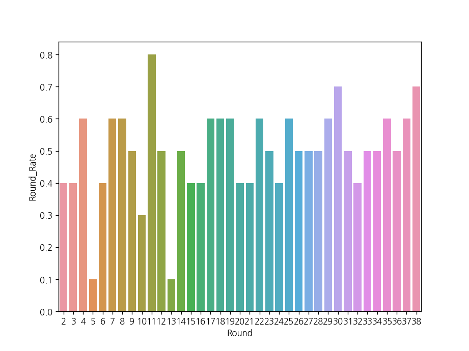

```python
import matplotlib.pyplot as plt
import seaborn as sns
%matplotlib notebook

sns.barplot(data=df, x="Round", y="Round_Rate")
plt.show()
```

## 라운드별 Round_rate

- 발생한 round_rate / 0.6 , 0.5 가 각각 11번으로 가장 많음 , 이후 0.4 9번 , 0.1 2번 , 0.7 2번 ,0.3과 0.8이 1번으로 나타났다.
- 2 ~ 13 라운드 사이에는 0.1 ~ 0.8 까지 다양한 round_rate 가 등장함
- 위와 같은 현상은 팀별로 순위가 고정되지 않고 자주 바뀌었기 떄문으로 보임
- 어느 정도 순위가 고정되는 14라운드 부터는 round_rate가 0.4 ~ 0.7 사이의 값을 가지는 것을 볼 수 있다

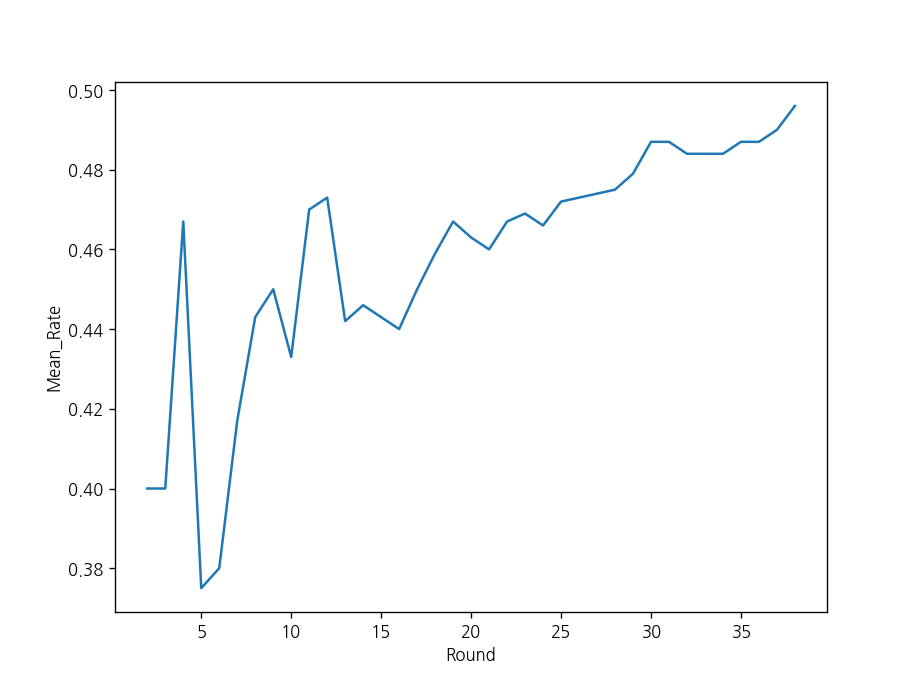

```python
sns.lineplot(data=df, x="Round", y="Mean_Rate")
plt.show()
```

## 라운드가 진행됨에 따라 나오는 Mean_rate

- mean_rate 역시 2 ~ 15 라운드 전까지는 0.38 ~ 0.47 사이의 값을 가지면서 변화폭이 매우 큰것을 볼 수 있다.
- 이후 15라운드 이후부터는 순위가 정립되고 강팀과 약팀이 순위에 따라 정리되면서 mean_rate는 점점 상승한다.
- 그럼에도 불구하고 최종 38라운드 까지의 전체 normal_rate의 평균인 mean_rate는 0.5를 넘지 못하고 있다.